# Lab05_Ahmed_Rashwan

Ahmed Rashwan

```r
library( plyr)
library( dplyr )       # data wrangling
library( pander )      # nice tables
library( mclust )      # cluster analysis
```

```r
library( ggplot2 )     # graphing

library( DT )          # provides an R interface to the JavaScript library DataTables
library( knitr )       # Provides a general-purpose tool for dynamic report generation
library( stargazer )   # create a summary statistics table
library( scales )      # inverse of scaling, making guides (legends and axes)

# maps
library( tidycensus)   # help R users get Census data that is pre-prepared for exploration
library( pals )        # Memory use is reduced by compressing colormaps to fewer colors
library( cartogram )   # spatial maps w/ tract size bias reduction
library( tidyverse)    # tidyverse makes data science faster, easier and more fun with
library( here)
library(formattable)
customGreen0 = "#DeF7E9"

customGreen = "#71CA97"

customRed = "#ff7f7f"
```

```r
# load necessary functions and objects ----
# note: all of these are R objects that will be used throughout this .rmd file
import::here("S_TYPE",
             "panel.cor",
             "panel.smooth",
             "d",
             "df",
             "d3",
             "d6",
             "PLOTS",
             "%>%",
             # notice the use of here::here() that points to the .R file
             # where all these R objects are created
             .from = here::here("labs/wk05/lab_05_source.R"),
             .character_only = TRUE)
```

#### Saving our rodeo file into rodeo file

```r
saveRDS(d,here("data/rodeo/rodeo-data-AR.rds"))
```

#### Loading our d file from the rds format

```r
readRDS(file=here("data/rodeo/rodeo-data-AR.rds"))
```

#### Loading Data Manifest from our rodeo folder

```r
# Year 2000 Data
ltdb.raw.2000s <- read.csv(here("data/raw/ltdb_std_2000_sample.csv"))
ltdb.raw.2000f <- read.csv(here("data/raw/LTDB_Std_2000_fullcount.csv"))
ltdb.rodeo.2000 <- readRDS(here("data/rodeo/LTDB-2000.rds"))

# Year 2010 Data
ltdb.raw.2010s <- read.csv(here("data/raw/ltdb_std_2010_sample.csv"))
ltdb.raw.2010f <- read.csv(here("data/raw/LTDB_Std_2010_fullcount.csv"))
ltdb.rodeo.2010 <- readRDS(here("data/rodeo/LTDB-2010.rds"))

complete.rodeo <-readRDS(file=here("data/rodeo/rodeo-data-AR.rds"))
```

```r
head(d) %>% pander()
```

Table continues below

| tractid | cbsa | cbsaname | mhv.00 | mhv.10 | mhv.change |
| --- | --- | --- | --- | --- | --- |
| fips-01-001-020100 | 33860 | Montgomery, AL | 98703 | 121500 | 22797 |
| fips-01-001-020200 | 33860 | Montgomery, AL | 93935 | 130500 | 36565 |
| fips-01-001-020300 | 33860 | Montgomery, AL | 102955 | 118700 | 15745 |
| fips-01-001-020400 | 33860 | Montgomery, AL | 115712 | 133500 | 17788 |
| fips-01-001-020500 | 33860 | Montgomery, AL | 150237 | 174500 | 24263 |
| fips-01-001-020600 | 33860 | Montgomery, AL | 90714 | 129600 | 38886 |

Table continues below

| mhv.growth | hinc00 | hu00 | own00 | rent00 | hinc12 | hu10 | own10 | rent10 |
| --- | --- | --- | --- | --- | --- | --- | --- | --- |
| 23.1 | 47270 | 769 | 518 | 158 | 56500 | 752 | 536 | 157 |
| 38.93 | 39040 | 731 | 452 | 212 | 41250 | 822 | 469 | 274 |
| 15.29 | 60215 | 1263 | 869 | 333 | 43088 | 1326 | 949 | 307 |
| 15.37 | 59456 | 1871 | 1390 | 370 | 54503 | 1823 | 1357 | 365 |
| 16.15 | 75878 | 2282 | 1671 | 531.3 | 65027 | 4308 | 2459 | 1623 |
| 42.87 | 43423 | 1310 | 960.9 | 209.2 | 52639 | 1452 | 1014 | 297 |

Table continues below

| empclf00 | clf00 | unemp00 | prof00 | empclf12 | clf12 | unemp12 | prof12 |
| --- | --- | --- | --- | --- | --- | --- | --- |
| 826 | 872 | 46 | 221 | 858 | 878 | 32 | 240 |
| 722 | 802 | 80 | 154 | 880 | 1010 | 134 | 352 |
| 1414 | 1456 | 42 | 438 | 1408 | 1423 | 36 | 437 |
| 2114 | 2191 | 77 | 673 | 1825 | 2005 | 206 | 596 |
| 2906 | 2955 | 49.35 | 1173 | 5037 | 5224 | 201 | 2123 |
| 1497 | 1584 | 87.18 | 364.2 | 1426 | 1583 | 177 | 370 |

Table continues below

| dpov00 | npov00 | dpov12 | npov12 | ag25up00 | hs00 | col00 | ag25up12 | hs12 |
| --- | --- | --- | --- | --- | --- | --- | --- | --- |
| 1790 | 227 | 1764 | 163 | 1227 | 635 | 192 | 1206 | 687 |
| 1907 | 433 | 2074 | 218 | 1157 | 740 | 170 | 1442 | 745 |
| 3262 | 250 | 3104 | 367 | 2130 | 990 | 478 | 2082 | 1006 |
| 4551 | 207 | 4337 | 136 | 3072 | 1477 | 708 | 2998 | 1242 |
| 6048 | 223.3 | 10431 | 807 | 3785 | 1257 | 1214 | 6351 | 1940 |
| 3272 | 497.9 | 3490 | 640 | 1977 | 1179 | 317.7 | 2136 | 1118 |

Table continues below

| col12 | pop00.x | nhwht00 | nhblk00 | hisp00 | asian00 | pop10 | nhwht10 |
| --- | --- | --- | --- | --- | --- | --- | --- |
| 287 | 1921 | 1723 | 145 | 12 | 8 | 1912 | 1601 |
| 349 | 1892 | 671 | 1177 | 16 | 12 | 2170 | 844 |
| 292 | 3339 | 2738 | 498 | 55 | 27 | 3373 | 2538 |
| 785 | 4556 | 4273 | 118 | 101 | 40 | 4386 | 4030 |
| 2569 | 6054 | 5427 | 367.5 | 95.24 | 113.1 | 10766 | 8438 |
| 438 | 3272 | 2615 | 553.1 | 63.93 | 10.65 | 3668 | 2672 |

Table continues below

| nhblk10 | hisp10 | asian10 | num.nmtc | nmtc.total | num.lihtc | lihtc.total |
| --- | --- | --- | --- | --- | --- | --- |
| 228 | 44 | 16 | 0 | 0 | 0 | 0 |
| 1226 | 75 | 13 | 0 | 0 | 0 | 0 |
| 668 | 87 | 42 | 0 | 0 | 1 | 2e+05 |
| 205 | 85 | 35 | 0 | 0 | 0 | 0 |
| 1504 | 355 | 373 | 0 | 0 | 2 | 1304122 |
| 776 | 176 | 19 | 0 | 0 | 0 | 0 |

Table continues below

| p.white.00 | p.black.00 | p.hisp.00 | p.asian.00 | p.hs.edu.00 | p.col.edu.00 |
| --- | --- | --- | --- | --- | --- |
| 89.69 | 7.548 | 0.6247 | 0.4164 | 67.4 | 15.65 |
| 35.47 | 62.21 | 0.8457 | 0.6342 | 78.65 | 14.69 |
| 82 | 14.91 | 1.647 | 0.8086 | 68.92 | 22.44 |
| 93.79 | 2.59 | 2.217 | 0.878 | 71.13 | 23.05 |
| 89.64 | 6.07 | 1.573 | 1.867 | 65.29 | 32.07 |
| 79.93 | 16.9 | 1.954 | 0.3256 | 75.7 | 16.07 |

Table continues below

| p.prof.00 | p.unemp.00 | pov.rate.00 | p.white.10 | p.black.10 | p.hisp.10 |
| --- | --- | --- | --- | --- | --- |
| 26.76 | 5.275 | 12.68 | 83.73 | 11.92 | 2.301 |
| 21.33 | 9.975 | 22.71 | 38.89 | 56.5 | 3.456 |
| 30.98 | 2.885 | 7.664 | 75.24 | 19.8 | 2.579 |
| 31.84 | 3.514 | 4.548 | 91.88 | 4.674 | 1.938 |
| 40.38 | 1.67 | 3.692 | 78.38 | 13.97 | 3.297 |
| 24.34 | 5.505 | 15.22 | 72.85 | 21.16 | 4.798 |

Table continues below

| p.asian.10 | p.hs.edu.10 | p.col.edu.10 | p.prof.10 | p.unemp.10 | pov.rate.10 |
| --- | --- | --- | --- | --- | --- |
| 0.8368 | 80.76 | 23.8 | 27.97 | 3.645 | 9.24 |
| 0.5991 | 75.87 | 24.2 | 40 | 13.27 | 10.51 |
| 1.245 | 62.34 | 14.02 | 31.04 | 2.53 | 11.82 |
| 0.798 | 67.61 | 26.18 | 32.66 | 10.27 | 3.136 |
| 3.465 | 71 | 40.45 | 42.15 | 3.848 | 7.737 |
| 0.518 | 72.85 | 20.51 | 25.95 | 11.18 | 18.34 |

Table continues below

| metro.mhv.pct.00 | metro.mhv.pct.10 | metro.median.pay.00 |
| --- | --- | --- |
| 43 | 51 | 47630 |
| 36 | 57 | 47630 |
| 47 | 48 | 47630 |
| 59 | 63 | 47630 |
| 73 | 77 | 47630 |
| 33 | 55 | 47630 |

Table continues below

| metro.median.pay.10 | metro.diversity.rank.00 | metro.pop.total.00 |
| --- | --- | --- |
| 44410 | 8 | 345683 |
| 44410 | 70 | 345683 |
| 44410 | 21 | 345683 |
| 44410 | 3 | 345683 |
| 44410 | 9 | 345683 |
| 44410 | 25 | 345683 |

Table continues below

| metro.pop.total.10 | metro.mhv.pctile.change | metro.pay.change |
| --- | --- | --- |
| 373913 | 8 | -3220 |
| 373913 | 21 | -3220 |
| 373913 | 1 | -3220 |
| 373913 | 4 | -3220 |
| 373913 | 4 | -3220 |
| 373913 | 22 | -3220 |

| metro.pop.growth | increase.p.white | LIHTC | NMTC | growth |
| --- | --- | --- | --- | --- |
| 0.08166 | -5.959 | NO | NO | 23.1 |
| 0.08166 | 3.429 | NO | NO | 38.93 |
| 0.08166 | -6.756 | YES | NO | 15.29 |
| 0.08166 | -1.905 | NO | NO | 15.37 |
| 0.08166 | -11.27 | YES | NO | 16.15 |
| 0.08166 | -7.083 | NO | NO | 42.87 |

#### Stats of Both Years

```r
df <- select( df, MedianHomeValue2000,MedianHomeValue2010,MHV.Change.00.to.10,MHV.Growth.00.to.12)

formattable(head(df),
            align =c("l","c","c","c","c", "c", "c", "c", "r"),
            list(`Indicator Name` = formatter(
            "span", style = ~ style(color = "grey",font.weight = "bold")),
            `MedianHomeValue2000`= color_tile(customGreen, customGreen),
            `MedianHomeValue2010`= color_tile(customGreen0, customGreen0),
            `MHV.Change.00.to.10`= color_tile(customGreen, customGreen),
            `MHV.Growth.00.to.12`= color_tile(customRed, customRed)
))
```

| MedianHomeValue2000 | MedianHomeValue2010 | MHV.Change.00.to.10 | MHV.Growth.00.to.12 |
| --- | --- | --- | --- |
| 98702.93 | 121500 | 22797.07 | 23.09665 |
| 93935.30 | 130500 | 36564.70 | 38.92542 |
| 102955.15 | 118700 | 15744.85 | 15.29293 |
| 115711.79 | 133500 | 17788.21 | 15.37286 |
| 150236.59 | 174500 | 24263.41 | 16.15013 |
| 90713.92 | 129600 | 38886.08 | 42.86672 |

#### Median Home value 2000

[figure not shown]

```r
hist( df$MedianHomeValue2000, breaks=200, xlim=c(0,500000),
      col="gray20", border="white",
      axes=F,
      xlab="MHV (median = $138k)",
      ylab="",
      main="Median Home Value in 2000 ( 2010 US dollars)" )
axis( side=1, at=seq(0,500000,100000),
      labels=c("$0","$100k","$200k","$300k","$400k","$500k") )
abline( v=median(df$MedianHomeValue2000, na.rm=T ), col="orange", lwd=3 )
```

#### Median Home value 2010

[figure not shown]

```r
hist( df$MedianHomeValue2010, breaks=200, xlim=c(0,500000),
      col="gray20", border="white",
      axes=F,
      xlab="MHV (median = $155k)",
      ylab="",
      main="Median Home Value in 2010 ( 2010 US dollars)" )
axis( side=1, at=seq(0,500000,100000),
      labels=c("$0","$100k","$200k","$300k","$400k","$500k") )
abline( v=median(df$MedianHomeValue2010, na.rm=T ), col="orange", lwd=3 )
```

#### Change Value in Median Home Value 2000 to 2010

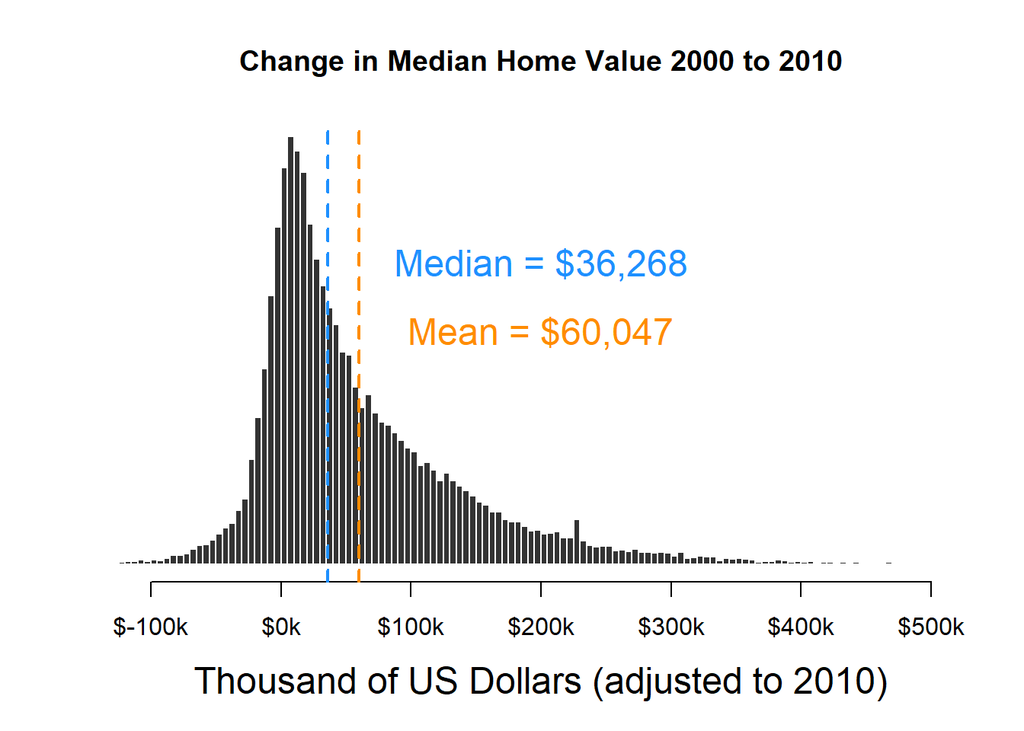

```r
hist( df$MHV.Change.00.to.10/1000, breaks=500,
      xlim=c(-100,500), yaxt="n", xaxt="n",
      xlab="Thousand of US Dollars (adjusted to 2010)", cex.lab=1.5,
      ylab="", main="Change in Median Home Value 2000 to 2010",
      col="gray20", border="white" )
axis( side=1, at=seq( from=-100, to=500, by=100 ),
      labels=paste0( "$", seq( from=-100, to=500, by=100 ), "k" ) )

mean.x <- mean( df$MHV.Change.00.to.10/1000, na.rm=T )
abline( v=mean.x, col="darkorange", lwd=2, lty=2 )
text( x=200, y=1500,
      labels=paste0( "Mean = ", dollar( round(1000*mean.x,0)) ),
      col="darkorange", cex=1.5, pos=3 )
median.x <- median( df$MHV.Change.00.to.10/1000, na.rm=T )
abline( v=median.x, col="dodgerblue", lwd=2, lty=2 )
text( x=200, y=2000,
      labels=paste0( "Median = ", dollar( round(1000*median.x,0)) ),
      col="dodgerblue", cex=1.5, pos=3 )
```

#### Growth Percentage in Home Value by Census Tract 2000 to 2010

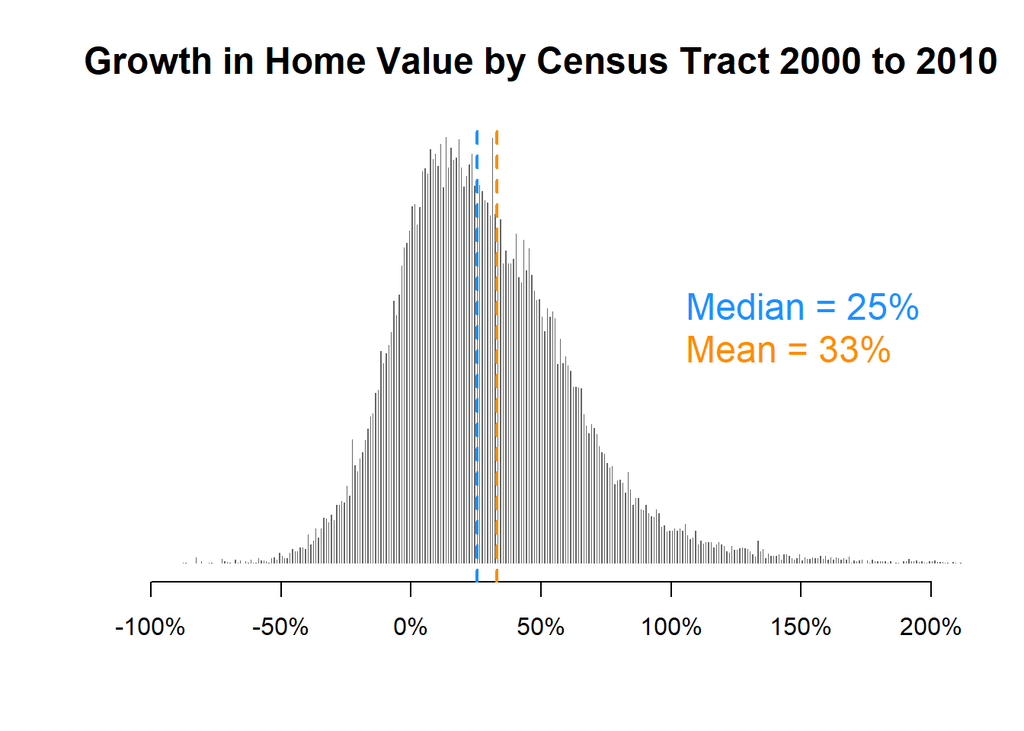

```r
hg <-
hist( df$MHV.Growth.00.to.12, breaks=5000,
      xlim=c(-100,200), yaxt="n", xaxt="n",
      xlab="", cex.main=1.5,
      ylab="", main="Growth in Home Value by Census Tract 2000 to 2010",
      col="gray40", border="white" )
axis( side=1, at=seq( from=-100, to=200, by=50 ),
      labels=paste0( seq( from=-100, to=200, by=50 ), "%" ) )
ymax <- max( hg$count )

mean.x <- mean( df$MHV.Growth.00.to.12, na.rm=T )
abline( v=mean.x, col="darkorange", lwd=2, lty=2 )
text( x=100, y=(0.5*ymax),
      labels=paste0( "Mean = ", round(mean.x,0), "%"),
      col="darkorange", cex=1.5, pos=4 )
median.x <- median( df$MHV.Growth.00.to.12, na.rm=T )
abline( v=median.x, col="dodgerblue", lwd=2, lty=2 )
text( x=100, y=(0.6*ymax),
      labels=paste0( "Median = ", round(median.x,0), "%"),
      col="dodgerblue", cex=1.5, pos=4 )
```

#### Descriptive Statistics

```r
stargazer::stargazer( df,
                      type=S_TYPE,
                      digits=0,
                      summary.stat = c("min", "p25","median","mean","p75","max") )
```

```
##
## ==========================================================================
## Statistic              Min     Pctl(25) Median   Mean   Pctl(75)    Max
## --------------------------------------------------------------------------
## MedianHomeValue2000   11,167   105,661  154,903 187,129 224,337  1,288,551
## MedianHomeValue2010   9,999    123,200  193,200 246,570 312,000  1,000,001
## MHV.Change.00.to.10 -1,228,651  7,187   36,268  60,047   94,881  1,000,001
## MHV.Growth.00.to.12    -97        6       25      33       50      6,059
## --------------------------------------------------------------------------
```

### Bivariate Correlation

```r
df.instrument <- select(d, mhv.growth , p.white.00 , p.col.edu.00 , p.prof.00) %>%na.omit()
```

#### Correlation Plot for selected instruments

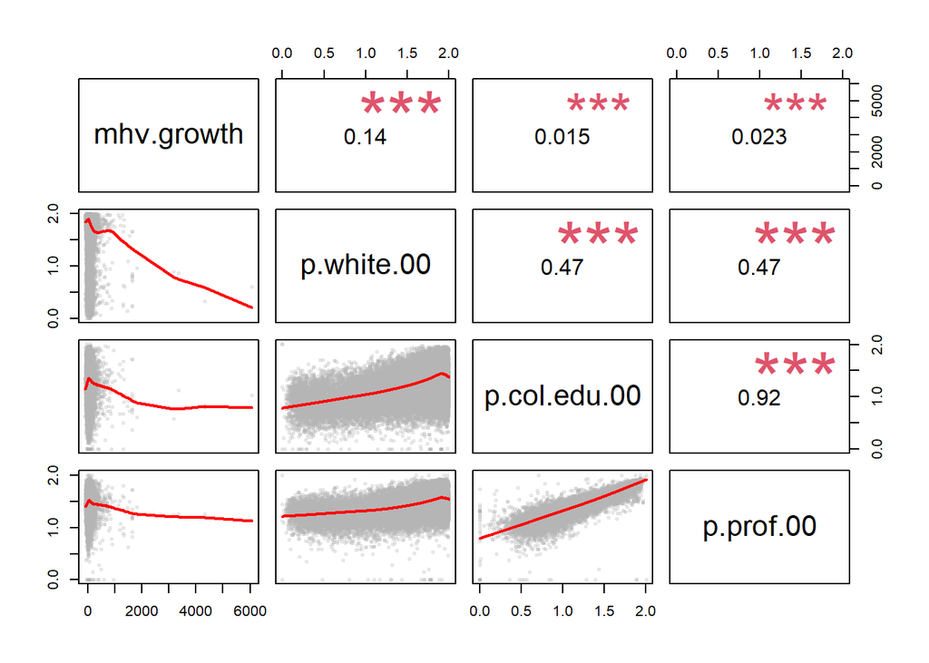

```r
set.seed(1234)
df.instrument$p.white.00 <- log10( df.instrument$p.white.00 + 1 )
df.instrument$p.col.edu.00 <- log10( df.instrument$p.col.edu.00 + 1  )
df.instrument$p.prof.00 <- log10( df.instrument$p.prof.00 + 1 )
# correlation plots
pairs( df.instrument, lower.panel=panel.smooth,upper.panel=panel.cor )
```

#### Variables Skew

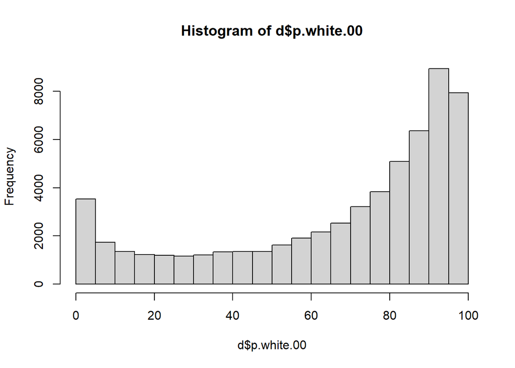

```r
hist( d$p.white.00 )
```

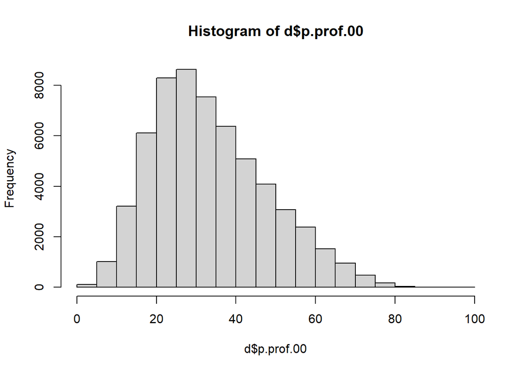

```r
hist( d$p.prof.00 )
```

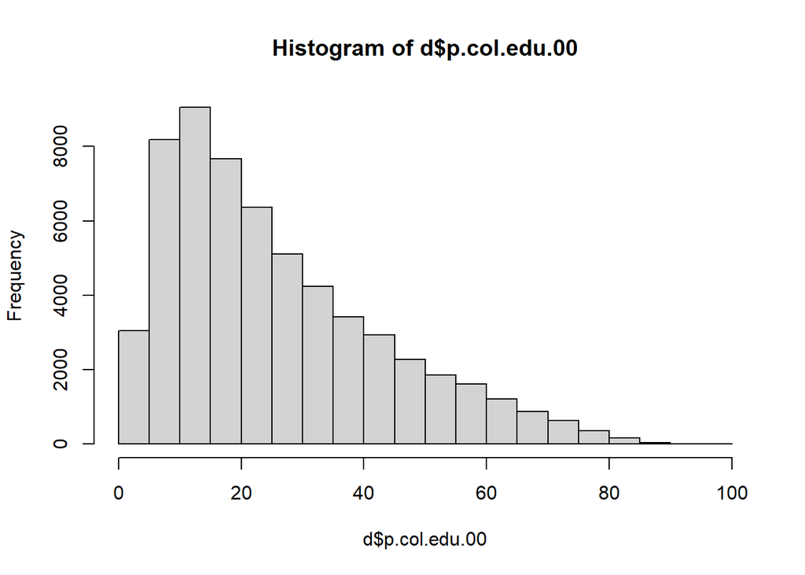

```r
hist( d$p.col.edu.00 )
```

### Variable Regression Analysis

```r
reggres <- lm(mhv.growth ~ p.white.00 + p.col.edu.00 + p.prof.00 , data = df.instrument)

stargazer(reggres, type = S_TYPE, dep.var.labels = ("Median Home Value change 2000-2010"),
    digits = 2)
```

```
##
## ======================================================
##                            Dependent variable:
##                     ----------------------------------
##                     Median Home Value change 2000-2010
## ------------------------------------------------------
## p.white.00                      -28.23***
##                                   (0.75)
##
## p.col.edu.00                     17.67***
##                                   (2.16)
##
## p.prof.00                         -5.67*
##                                   (3.44)
##
## Constant                         66.45***
##                                   (2.81)
##
## ------------------------------------------------------
## Observations                      59,066
## R2                                 0.02
## Adjusted R2                        0.02
## Residual Std. Error         65.61 (df = 59062)
## F Statistic             488.01*** (df = 3; 59062)
## ======================================================
## Note:                      *p<0.1; **p<0.05; ***p<0.01
```

### Program Participation Criteria

#### DATA TO BE USED FOR THE DIFF-DIFF MODEL

```r
#  DATA TO BE USED FOR THE DIFF-DIFF MODEL FOR NMTC PROGRAM

head(d3) %>% pander()
```

| y | treat | post |
| --- | --- | --- |
| 11.5 | 0 | 0 |
| 11.45 | 0 | 0 |
| 11.54 | 0 | 0 |
| 11.66 | 0 | 0 |
| 11.92 | 0 | 0 |
| 11.42 | 0 | 0 |

```r
#  DATA TO BE USED FOR THE DIFF-DIFF MODEL FOR LIHTC PROGRAM

head(d6) %>% pander()
```

| y | treat2 | post2 |
| --- | --- | --- |
| 11.5 | 0 | 0 |
| 11.45 | 0 | 0 |
| 11.54 | 1 | 0 |
| 11.66 | 0 | 0 |
| 11.92 | 1 | 0 |
| 11.42 | 0 | 0 |

#### Recipient and Non-Recipient Tracts:

#### We can look at some descriptive statistics from 2000 to determine if we have an apples to oranges type of comparison:

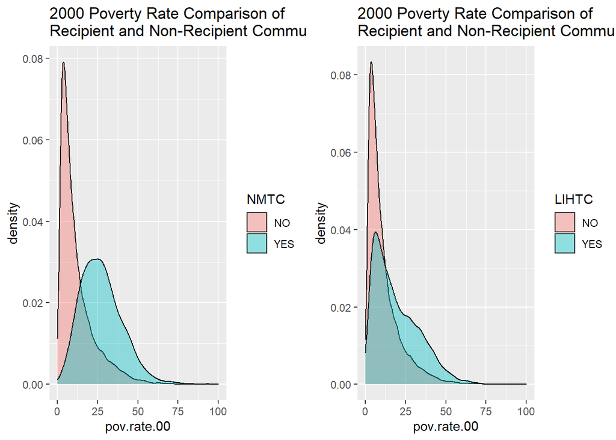

```r
### POVERTY RATES
gridExtra::grid.arrange( PLOTS$pov_rate_2000$nmtc,
                         PLOTS$pov_rate_2000$lihtc,
                         nrow = 1 )
```

##### New Market Tax Credit recipients appear to be quite distinct, located in poorer tracts. We see the LIHTC projects tend to favor tracts with higher poverty than non-recipient tracts, but a large proportion of the projects are still located in tracts with low to moderate levels of poverty.

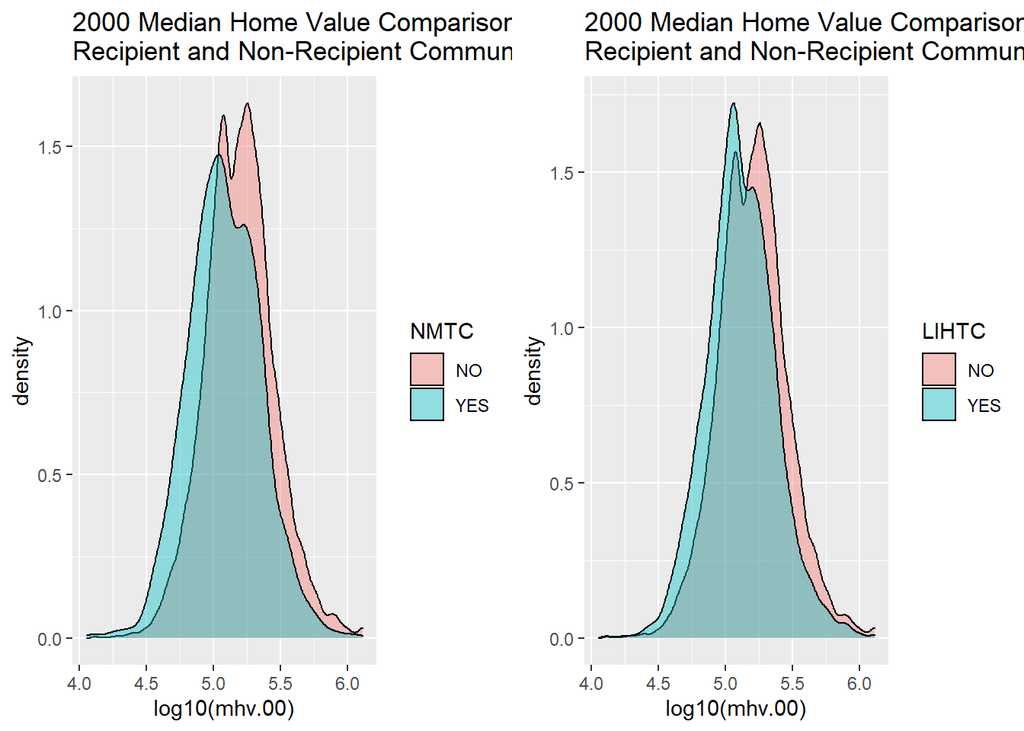

```r
### HOME VALUES
gridExtra::grid.arrange( PLOTS$mhv_2000$nmtc,
                         PLOTS$mhv_2000$lihtc,
                         nrow = 1 )
```

##### When comparing recipient tracts to non-recipient tracts we can see very clearly that they are different. The degree depends on the program, NMTC seem to be very distinctive, and LIHTC still different but not as pronounced.

### Here are some more summary statistics comparing the two:

**Household Income 2000 Variable:**

#### LIHTC Program

```r
### HOUSEHOLD INCOME COMPARISONIN 2000:
### PROGRAM RECIPIENTS VS NON-RECIPIENT TRACTS

# Tracts that received LIHTC
mean( d$hinc00[ d$num.lihtc > 0 ] )
```

```
## [1] 47302.67
```

```r
# Tracts that did not received LIHT
mean( d$hinc00[ d$num.lihtc == 0 ] )
```

```
## [1] 63789.16
```

```r
# Tracts that received NMTC
mean( d$hinc00[ d$num.nmtc > 0 ] )
```

```
## [1] 35792.88
```

**Home Value 2000 Variable:**

#### LIHTC Program

```r
### MEDIAN HOME VALUE COMPARISON IN 2000

# Tracts that received LIHTC
mean( d$mhv.00[ d$num.lihtc > 0 ], na.rm=T )
```

```
## [1] 156532.2
```

```r
# Tracts that did not received LIHTC

mean( d$mhv.00[ d$num.lihtc == 0 ], na.rm=T )
```

```
## [1] 192122.5
```

#### NMTC Program

```r
# Tracts that received NMTC
mean( d$mhv.00[ d$num.nmtc > 0 ], na.rm=T )
```

```
## [1] 146691.6
```

```r
# Tracts that did not received NMTC
mean( d$mhv.00[ d$num.nmtc == 0 ], na.rm=T )
```

```
## [1] 188383
```

**Poverty Rates 2000 Variable:**

#### LIHTC Program

```r
### POVERTY RATE COMPARISONS

# Tracts that received LIHTC
summary( d$pov.rate.00[ d$num.lihtc > 0 ] )
```

```
##    Min. 1st Qu.  Median    Mean 3rd Qu.    Max.
##   0.000   7.977  15.869  19.340  28.548  88.210
```

```r
### POVERTY RATE COMPARISONS

# Tracts that did not received LIHTC
summary( d$pov.rate.00[ d$num.lihtc == 0 ] )
```

```
##    Min. 1st Qu.  Median    Mean 3rd Qu.    Max.
##   0.000   4.144   7.766  11.204  14.707 100.000
```

#### NMTC Program

```r
### POVERTY RATE COMPARISONS

# Tracts that received NMTC
summary( d$pov.rate.00[ d$num.nmtc > 0 ] )
```

```
##    Min. 1st Qu.  Median    Mean 3rd Qu.    Max.
##    0.00   17.74   26.10   27.28   34.89   93.17
```

```r
### POVERTY RATE COMPARISONS

# Tracts that did not received NMTC
summary( d$pov.rate.00[ d$num.nmtc == 0 ] )
```

```
##    Min. 1st Qu.  Median    Mean 3rd Qu.    Max.
##   0.000   4.335   8.218  11.893  15.768 100.000
```

**DV of MHV growth rates Variable:**

### And examining the DV of MHV growth rates to get a sense of the distribution of the outcome prior to running regression models:

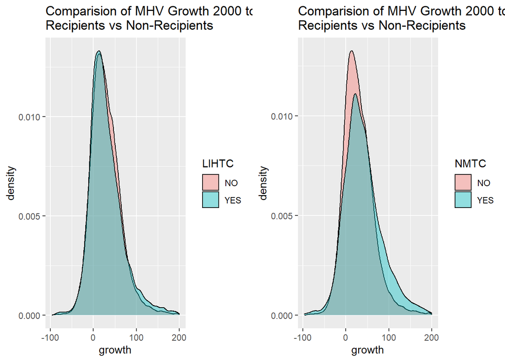

```r
### MHV Growth Rates (DV in Model)
gridExtra::grid.arrange( PLOTS$mhv_growth$lihtc,
                         PLOTS$mhv_growth$nmtc,
                         nrow = 1 )
```

**LIHTC on the left is a bit misleading since there is greater density for program participant tracts in the right tail (evidence of higher treatment growth), but there is also some more density for non-participant tracts in the peak left of the distribution. It’s difficult to judge visually.**

**NMTC, on the other hand, appears to be in better shape because to the high density in the right side.**

**We can confirm these with some descriptive statistics of home value growth rates:**

#### LIHTC Program

```r
# Tracts that received LIHTC
summary( d$growth[ d$num.lihtc > 0 ] )
```

```
##    Min. 1st Qu.  Median    Mean 3rd Qu.    Max.    NA's
## -88.967   4.216  23.006  29.821  48.740 199.739     115
```

```r
# Tracts that did not received LIHTC
summary( d$growth[ d$num.lihtc == 0 ] )
```

```
##    Min. 1st Qu.  Median    Mean 3rd Qu.    Max.    NA's
## -96.891   5.963  25.160  29.307  48.678 199.550     385
```

#### NMTC Program

```r
# Tracts that received NMTC
summary( d$growth[ d$num.nmtc > 0 ] )
```

```
##    Min. 1st Qu.  Median    Mean 3rd Qu.    Max.    NA's
##  -94.55   11.01   33.58   39.63   62.96  199.31      56
```

```r
# Tracts that did not received NMTC
summary( d$growth[ d$num.nmtc == 0 ] )
```

```
##    Min. 1st Qu.  Median    Mean 3rd Qu.    Max.    NA's
## -96.891   5.587  24.701  29.087  48.356 199.739     444
```

**Home value growth rates for LIHTC program participant and non-participant tracts are almost the same.**

**Home value growth rates for NMTC participants are significant higher than non-participant tracts. These are unconditional means with no real counterfactual, so we still need to create an evaluation framework. But they offer some suggestive evidence.**

### Evaluating Program Impact for NMTC Program

```r
m <- lm( y ~  treat + post +  treat*post, data=d3 )
# display model results
stargazer::stargazer(m,
                     type = S_TYPE,
                     digits = 2)
```

```
##
## ================================================
##                         Dependent variable:
##                     ----------------------------
##                                  y
## ------------------------------------------------
## treat                         -0.26***
##                                (0.02)
##
## post                          0.23***
##                               (0.004)
##
## treat:post                    0.10***
##                                (0.02)
##
## Constant                      11.96***
##                               (0.003)
##
## ------------------------------------------------
## Observations                  118,132
## R2                              0.04
## Adjusted R2                     0.04
## Residual Std. Error      0.64 (df = 118128)
## F Statistic         1,432.34*** (df = 3; 118128)
## ================================================
## Note:                *p<0.1; **p<0.05; ***p<0.01
```

```r
# Exponentiate coefficients to recover the mean:

b0 <- m$coefficients[1]
b1 <- m$coefficients[2]
b2 <- m$coefficients[3]
b3 <- m$coefficients[4]

# C1 = B0
exp( b0 )
```

```
## (Intercept)
##    156581.4
```

```r
# C2 = B0 + B2
exp( b0 + b2 )
```

```
## (Intercept)
##    196984.4
```

```r
# T1 = B0 + B1
exp( b0 + b1 )
```

```
## (Intercept)
##    120265.3
```

```r
# T2 = B0 + B1 + B2 + B3
exp( b0+b1+b2+b3 )
```

```
## (Intercept)
##    166560.5
```

### Evaluating Program Impact for LIHTC Program

```r
m2 <- lm( y ~  treat2 + post2 +  treat2*post2, data=d6 )
# display model results
stargazer::stargazer(m2,
                     type = S_TYPE,
                     digits = 2)
```

```
##
## ================================================
##                         Dependent variable:
##                     ----------------------------
##                                  y
## ------------------------------------------------
## treat2                        -0.21***
##                                (0.01)
##
## post2                         0.23***
##                               (0.004)
##
## treat2:post2                    0.01
##                                (0.01)
##
## Constant                      11.98***
##                               (0.003)
##
## ------------------------------------------------
## Observations                  118,132
## R2                              0.04
## Adjusted R2                     0.04
## Residual Std. Error      0.64 (df = 118128)
## F Statistic         1,799.55*** (df = 3; 118128)
## ================================================
## Note:                *p<0.1; **p<0.05; ***p<0.01
```

```r
# Exponentiate coefficients to recover the mean:

b0 <- m2$coefficients[1]
b1 <- m2$coefficients[2]
b2 <- m2$coefficients[3]
b3 <- m2$coefficients[4]

# C1 = B0
exp( b0 )
```

```
## (Intercept)
##    159936.6
```

```r
# C2 = B0 + B2
exp( b0 + b2 )
```

```
## (Intercept)
##    201589.5
```

```r
# T1 = B0 + B1
exp( b0 + b1 )
```

```
## (Intercept)
##    129977.4
```

```r
# T2 = B0 + B1 + B2 + B3
exp( b0+b1+b2+b3 )
```

```
## (Intercept)
##    164796.4
```